# IMDB Data Analysis

April 8th, 2019

## Where Do We Start?

## Background

- **Movies**, also known as films, are a type of visual communication which uses moving pictures and sound to tell stories or teach people something.
- Movies are appealing a rapidly-increasing number of audience.
- The questions that I’m interested in are listed delow:
  - Which factors are of importance in making the movies popular, and how to predict the audience rating.
  - How to determine whether the investment on a movie is profiable or not.
  - How to build a recommender system for the movie audience.
  - etc

## Data Description

- The two datasets comes from [Kaggle](https://www.kaggle.com/), and we combine them.
- The combined dataset contains nearly \(5000\) movies, and after removing NA rows \(3636\) pieces are left
- The variables are listed on the next page

## Data Description

```
##  [1] "actor_1_facebook_likes"    "actor_1_name"
##  [3] "actor_2_facebook_likes"    "actor_2_name"
##  [5] "actor_3_facebook_likes"    "actor_3_name"
##  [7] "aspect_ratio"              "budget"
##  [9] "cast_total_facebook_likes" "color"
## [11] "content_rating"            "country"
## [13] "director_facebook_likes"   "director_name"
## [15] "facenumber_in_poster"      "genres"
## [17] "gross"                     "imdb_score"
## [19] "language"                  "movie_facebook_likes"
## [21] "movie_title"               "num_critic_for_reviews"
## [23] "num_user_for_reviews"      "num_voted_users"
## [25] "overview"                  "plot_keywords"
## [27] "popularity"                "production_companies"
## [29] "runtime"                   "title_year"
## [31] "return_rate"               "if_profit"
## [33] "total_fb_likes"
```

## Data Description

- We explain some variables here:
  - aspect_ratio: the aspect ratio of a movie
  - actor_x_name / actor_x_facbook_likes: name and facebook like number of the actor
  - facenumber_in_poster: Contains number of actor’s faces on a movie poster
  - gross: the revenue of a movie in USD
  - genres: the sub-genres to which a movie belongs
  - imdb_score: the audience rating of a movie
  - movie_title: title of a movie
  - title_year: the year in which a film was released

## Data Description

- Considering inflation, it’s more reasonable to measure the revenue of a movie by a ratio, i.e. the return rate, \[ \text{return_rate} = \frac{\text{gross} - \text{budget}}{\text{budget}} \]
- We regard the **imdb_score** and **return_rate** as the response respectively and apply several machine learning techniques to predict.
- Whether a movie is profitable or not can also be treated as a \(0-1\) classification problem, so classifiction tools can be helpful.

## What Do We Want?

## Goal of Our Analysis

There are mainly three goals as listed below.

- Obtain a comprehensive knowledge of the dataset.
- Build a model to predict the IMDB score of a movie based on several variables.
- Build a model to determine whether a movie is profitable, or in other words, worth investing.

## How Do We Begin?

## Exploratory Data Analysis

- Display the proportion of movies making profit or loss.

[interactive chart not shown]

- The number of profitable movies is a bit larger, but we can still say that the dataset is balanced.

## Exploratory Data Analysis

- Check the distribution of **imdb_score**.

[interactive chart not shown]

## Exploratory Data Analysis

- Check the distribution of **budget** and **gross**, with the values outside their respective inter quartile ranges removed.

[interactive chart not shown]

## Exploratory Data Analysis

- Check if profitable movies recieve more appreciation by the users. Note that \(1\) represents profitable movies and \(0\) the others.

[interactive chart not shown]

- Obviously, profitable movies gain higher IMDB score in general. A t-test provides more evidence but we’re not going to show here.

## Exploratory Data Analysis

- Out of curiosity, we want to check if **imdb_score** is related to **release year**.

[interactive chart not shown]

- We set year 2000 as a boundary and find that there’s almost no difference in the distribution of **imdb_score** before and after that year.

## Exploratory Data Analysis

- Check the correlation between several variables

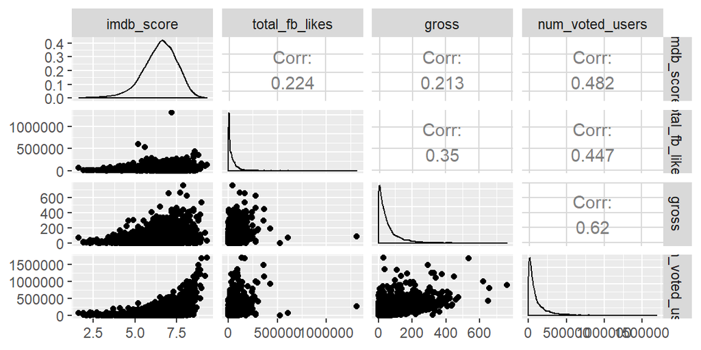

- This step helps us pick up the most significant variables, which can be used in regression analysis.
- Due to the limitation of space, we cannot show more EDA results.

## Which Models Can Help?

## Split the Dataset

As usual, we first split the dataset into training set and testing set.

```r
train_num = ceiling(0.8 * nrow(movie))
test_num = nrow(movie) - train_num
train_id = sample(1:nrow(movie), train_num)
train = movie[train_id, ]
test = movie[-train_id, ]
```

## Linear Regression

```
## [1] "For IMDB score, RMSE is 0.0323176935961944"
```

```
## [1] "For return rate, RMSE is 4.852942442259"
```

## Linear Regression

```
##
## Call:
## lm(formula = imdb_score ~ budget + runtime + total_fb_likes +
##     facenumber_in_poster + num_critic_for_reviews + num_user_for_reviews +
##     num_voted_users + aspect_ratio, data = train)
##
## Residuals:
##    Min     1Q Median     3Q    Max
## -4.719 -0.455  0.069  0.583  2.475
##
## Coefficients:
##                            Estimate   Std. Error t value
## (Intercept)             5.161606379  0.141024912   36.60
## budget                 -0.000063553  0.000048054   -1.32
## runtime                 0.016373684  0.000868786   18.85
## total_fb_likes         -0.000001175  0.000000387   -3.03
## facenumber_in_poster   -0.041149555  0.008341610   -4.93
## num_critic_for_reviews  0.001342501  0.000177322    7.57
## num_user_for_reviews   -0.000589539  0.000066161   -8.91
## num_voted_users         0.000003389  0.000000185   18.36
## aspect_ratio           -0.363733327  0.061638312   -5.90
##                                    Pr(>|t|)
## (Intercept)            < 0.0000000000000002 ***
## budget                               0.1861
## runtime                < 0.0000000000000002 ***
## total_fb_likes                       0.0024 **
## facenumber_in_poster      0.000000855237737 ***
## num_critic_for_reviews    0.000000000000049 ***
## num_user_for_reviews   < 0.0000000000000002 ***
## num_voted_users        < 0.0000000000000002 ***
## aspect_ratio              0.000000004029341 ***
## ---
## Signif. codes:  0 '***' 0.001 '**' 0.01 '*' 0.05 '.' 0.1 ' ' 1
##
## Residual standard error: 0.854 on 2900 degrees of freedom
## Multiple R-squared:  0.328,  Adjusted R-squared:  0.326
## F-statistic:  177 on 8 and 2900 DF,  p-value: <0.0000000000000002
```

## Support Vector Machine

```
## [1] "For IMDB score, RMSE is 0.0288510792981393"
```

```
## [1] "For return rate, RMSE is 4.95571214070708"
```

## Random Forest

```
## [1] "For IMDB score, RMSE is 0.0258844461167376"
```

```
## [1] "For return rate, RMSE is 3.96373475976991"
```

## Logistic Regression

```
## [1] "Correct prediction rate is 0.696011004126547"
```

## Summary

## Conclusions?

- Which variables are important?
- Which model to choose?
- Practical significance?
- What to do next?